# Willem Hovy

Bas Machielsen

## Introductie

Dit is een kort document om erachter te komen welke nalatenschappen van politici qua grootte/compositie vergelijkbaar zijn met die van W. Hovy. Ik kijk eerst naar collega-Eerste Kamerleden, en daarna probeer ik binnen een algemenere populatie van politici vermogens van een vergelijkbare grootte te identificeren. Uiteindelijk kom ik met verschillende lijstjes van politici van wie de vermogensgrootte en compositie vergelijkbaar is met die van W. Hovy.

## Welke mensen zaten er allemaal in de Eerste Kamer met W. Hovy?

Dit zijn alle personen die vanaf 1890 tot 1920 zijn gekozen in de Eerste Kamer. W. Hovy is gekozen in 1902 en is lid gebleven tot 1915.

| voorna_a_m_en | prepositie | achternaam |
| --- | --- | --- |
| Frederik Herman Pieter | van | Alphen |
| Hendrick Maurits Jan | van | Asch van Wijck |
| Titus Anthony Jacob | van | Asch van Wijck |
| Charles Augustus Henry | NA | Barge |
| Arnoldus Hyacinthus Maria | van | Berckel |
| Jean Gustave Stanislas | NA | Bevers |
| Petrus Johannes | van | Beyma |
| Auke | NA | Bloembergen |
| Reitze | NA | Bloembergen |
| Rembt Tobias Hugo Pieter Liebrecht Alexander | van | Boneval Faure |
| Henricus Paulus Cornelis | NA | Bosch van Drakestein |
| Willem Gerard | baron | Brantsen van de Zijp |
| Jan | NA | Breebaart |
| Cornelis Leonardus | NA | Bressers |
| Joseph Servatius Hubertus | NA | Brouwers |
| Franciscus Johannes Petrus Maria | NA | Coenen |
| Epimachus Jacobus Johannes Baptista | NA | Cremers |
| Willem Cornelis Johannes Josephus | NA | Cremers |
| Conrad Theodor | van | Deventer |
| Hendrik Lodewijk | NA | Drucker |
| Alexander Johannes | NA | Dijckmeester |
| Derck | NA | Engelberts |
| Hendrik | NA | Fennema |
| Pieter Marie Georges | von | Fisenne |
| Eduard | NA | Fokker |
| Johan Herman | NA | Geertsema |
| Johan George | NA | Gleichman |
| Maurits Cornelis | van | Hall |
| Jacob Petrus | NA | Havelaar |
| Jacob Derk Carel | baron van | Heeckeren van Kell |
| Gerrit Jan | van | Heek |
| Theodorus Everhardus Franciscus | NA | Heerkens |
| Samuel | van | Houten |
| Willem | NA | Hovy |
| Melchert | de | Jong |
| Herman Jacob | NA | Kist |
| Emile Alexis Marie | van der | Kun |
| Dirk | NA | Laan |
| Alphonsus Maria Josephus Ernestus Antonius | baron van | Lamsweerde |
| Wilhelmus Frederik | van | Leeuwen |
| Cornelis | NA | Lely |
| Constant Maurits Ernst | van | Löben Sels |
| Frans Godert | baron van | Lynden van Hemmen |
| Johannes Christiaan | de | Marez Oyens |
| Hendrik Rudolph | van | Marle |
| Hermanus Adrianus | NA | Nebbens Sterling |
| Anthony Ewoud Jan | NA | Nysingh |
| Egbertus | NA | Pelinck |
| Wilhelmus Josephus Hubertus | NA | Prinzen |
| Eduard Nicolaas | NA | Rahusen |
| Carolus Antonius Maria | NA | Raymakers |
| Louis Hubert Willem | NA | Regout |
| Isaäc Antoni | van | Roijen |
| Jan Willem Hendrik | NA | Rutgers van Rozenburg |
| Alphonsus Maria | NA | Sassen |
| Alexander Frederik | de | Savornin Lohman |
| Jan Elias Nicolaas | baron | Schimmelpenninck van der Oye |
| Emile Claude | baron | Sweerts de Landas Wyborgh |
| Edzard | NA | Tjarda van Starkenborgh Stachouwer |
| Petrus Jacobus Franciscus | NA | Vermeulen |
| Hendrik | NA | Waller |
| Theodorus Marius Theresius | van | Welderen baron Rengers |
| Jan Jacob | NA | Willinge |
| Jan | NA | Woltjer |
| Stephanus Martinus | van | Wijck |
| Carel Herman Aart | van der | Wijck |
| Emilius Henricus Josephus Maria | van | Zinnicq Bergmann |

## Hoe rijk waren die mensen precies?

- Data met alle Eerste kamerleden die gekozen zijn vanaf 1890 tot 1915.

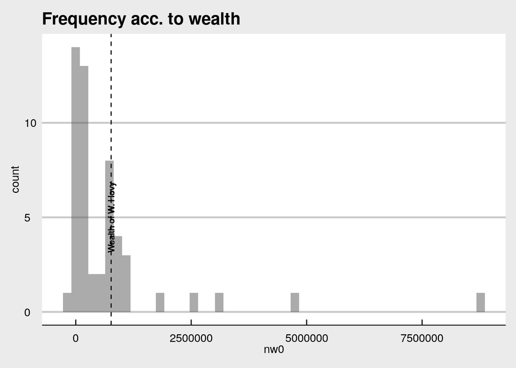

- Data zonder outliers

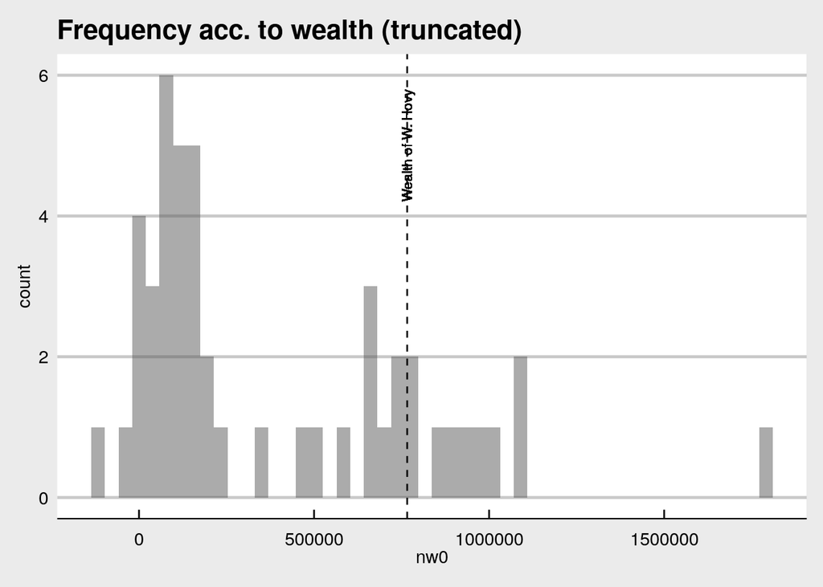

Laten we dus eens kijken naar welke mensen een netto vermogen hadden tussen de 500,000 en 1,000,000 gulden. Wie zijn dat?

| voorletters | prepositie | achternaam | netto_vermogen |
| --- | --- | --- | --- |
| H.P.C. | NA | Bosch van Drakestein | 786880.0 |
| W.G. | baron | Brantsen van de Zijp | 724361.0 |
| W.C.J.J. | NA | Cremers | 725366.4 |
| C.Th. | van | Deventer | 690315.0 |
| J.G. | NA | Gleichman | 663355.4 |
| W. | NA | Hovy | 765976.7 |
| M. | de | Jong | 981170.1 |
| H.R. | van | Marle | 650684.4 |
| W.J.H. | NA | Prinzen | 899497.1 |
| J.W.H. | NA | Rutgers van Rozenburg | 932582.3 |
| H. | NA | Waller | 668754.0 |
| S.M. | van | Wijck | 584226.8 |
| C.H.A. | van der | Wijck | 854530.3 |

- Hoe zag hun vermogenscompositie eruit?

Duprbo: Dutch private bonds  
Dugobo: Dutch government bonds  
Foprbo: Foreign private bonds  
Fogobo: Foreign government bonds  
Dush: Dutch shares  
Fosh: Foreign shares  
Re: Real estate  
Cash: cash  
Misc: Miscellaneous

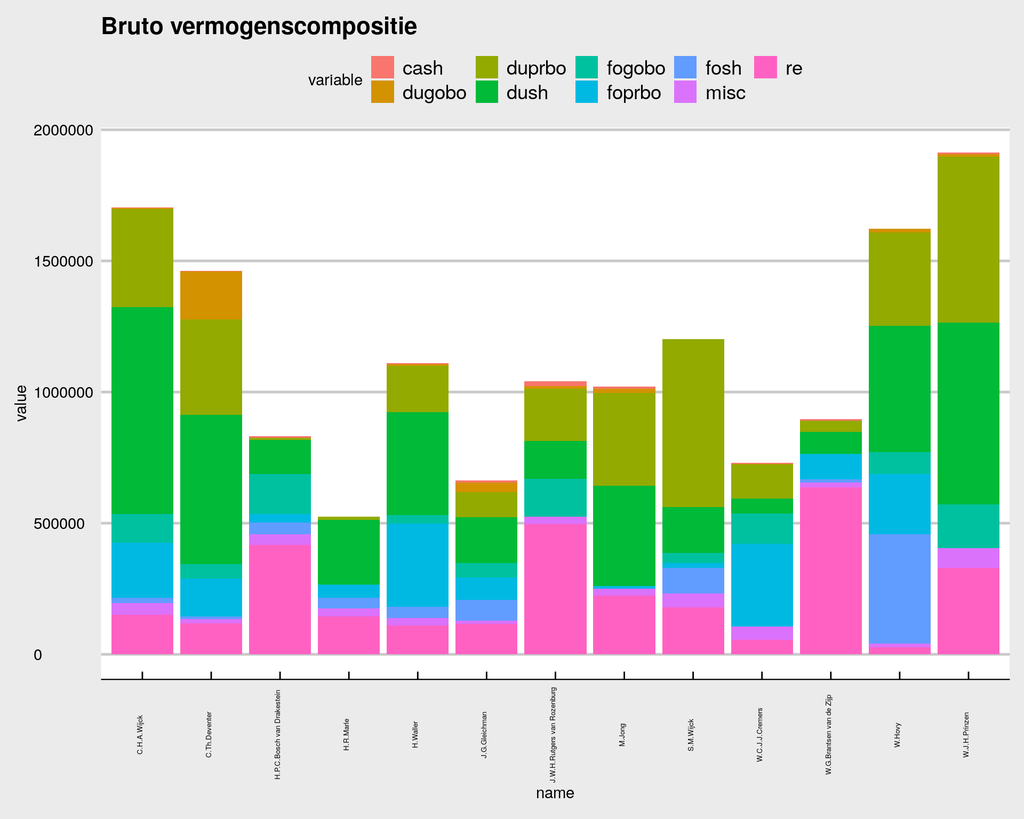

- Wat deden deze mensen in de rest van hun leven?

[output not shown]

[1] “H.P.C.Bosch van Drakestein met een vermogen van 786880 was in zijn leven landeigenaar en ambachtsheer, lid Provinciale Staten van Utrecht, dijkgraaf Hoogheemraadschap van de Lekdijk Bovendams, lid Eerste Kamer der Staten-Generaal, lid Eerste Kamer der Staten-Generaal”  
[2] “W.G.Brantsen van de Zijp met een vermogen van 724361 was in zijn leven landeigenaar, advocaat te Arnhem, commies van staat, Raad van State, kamerheer van prins Frederik, lid Tweede Kamer der Staten-Generaal, lid Tweede Kamer der Staten-Generaal, lid Tweede Kamer der Staten-Generaal, lid Eerste Kamer der Staten-Generaal”  
[3] “W.C.J.J.Cremers met een vermogen van 725366.44 was in zijn leven advocaat te Groningen, griffier kantongerecht te Winschoten, rechter Arrondissementsrechtbank te Appingedam, rechter Arrondissementsrechtbank te Winschoten, raadsheer Provinciaal Gerechtshof te Zwolle, raadsheer Gerechtshof te Arnhem, vicepresident Gerechtshof te Arnhem, lid gemeenteraad van Arnhem, lid Tweede Kamer der Staten-Generaal, lid Tweede Kamer der Staten-Generaal, lid Eerste Kamer der Staten-Generaal”  
[4] “C.Th.Deventer met een vermogen van 690315.01 was in zijn leven griffier Raad van Justitie te Amboina (Ned.-Indië), lid Raad van Justitie te Semarang (Ned.-Indië), advocaat, advocatenkantoor "Sloet van Hagensdorp" te Semarang (Ned.-Indië), lid gemeenteraad van Semarang (Ned.-Indië), verlof te Nederland, verlof te Nederland, publicist te Amsterdam, lid Tweede Kamer der Staten-Generaal, lid Eerste Kamer der Staten-Generaal, lid Tweede Kamer der Staten-Generaal”  
[5] “J.G.Gleichman met een vermogen van 663355.45 was in zijn leven advocaat bij de Hoge Raad der Nederlanden te ’s-Gravenhage, ambtenaar (resp. commies en referendaris), ministerie van Financiën, agent "De Nederlandsche Bank" te ’s-Gravenhage, secretaris "De Nederlandsche Bank" te Amsterdam, minister van Financiën, ambteloos, lid Tweede Kamer der Staten-Generaal, lid Tweede Kamer der Staten-Generaal, lid Tweede Kamer der Staten-Generaal, lid Tweede Kamer der Staten-Generaal, lid Tweede Kamer der Staten-Generaal, voorzitter Tweede Kamer der Staten-Generaal, lid Tweede Kamer der Staten-Generaal, voorzitter Tweede Kamer der Staten-Generaal, lid Eerste Kamer der Staten-Generaal”  
[6] “W.Hovy met een vermogen van 765976.7 was in zijn leven werkzaam bij "Van Vollenhovens Bierbrouwerij ‘De Gekroonde Valk’" te Amsterdam, procuratie-houder "Van Vollenhovens Bierbrouwerij ‘De Gekroonde Valk’" te Amsterdam, vennoot, Commanditaire Sociëteit firma "Van Vollenhoven en Co." te Amsterdam, lid gemeenteraad van Amsterdam, lid Provinciale Staten van Noord-Holland, directeur bierbrouwerij en azijnmakerij "De Gekroonde Valk" te Amsterdam, lid Eerste Kamer der Staten-Generaal, lid Eerste Kamer der Staten-Generaal”  
[7] “M.Jong met een vermogen van 981170.06 was in zijn leven kaas- en zaadhandelaar te Hoogkarspel, kaashandelaar, firma "K.H. de Jong" te Hoorn, lid gemeenteraad van Hoorn, lid Provinciale Staten van Noord-Holland, wethouder van Hoorn, lid Eerste Kamer der Staten-Generaal, lid Eerste Kamer der Staten-Generaal”  
[8] “H.R.Marle met een vermogen van 650684.41 was in zijn leven substituut-griffier Arrondissementsrechtbank te Deventer, burgemeester van Deventer, lid Provinciale Staten van Overijssel, kantonrechter te Deventer, lid Eerste Kamer der Staten-Generaal”  
[9] “W.J.H.Prinzen met een vermogen van 899497.05 was in zijn leven eigenaar bontweverij "Prinzen & van Glabbeek" te Helmond, margarinefabrikant, firma "Prinzen & van Glabbeek" te Helmond, Goch en Antwerpen, lid Provinciale Staten van Noord-Brabant, lid gemeenteraad van Helmond, lid Eerste Kamer der Staten-Generaal, lid Eerste Kamer der Staten-Generaal”  
[10] “J.W.H.Rutgers van Rozenburg met een vermogen van 932582.27 was in zijn leven advocaat te Amsterdam, kantonrechter-plaatsvervanger, tweede kanton te Amsterdam, consulent handelshuis in Nederlands-Indië, secretaris Amsterdamsche Kanaalmaatschappij, directeur Amsterdamsche Kanaalmaatschappij, lid Tweede Kamer der Staten-Generaal, lid Provinciale Staten van Noord-Holland, lid Tweede Kamer der Staten-Generaal, lid Tweede Kamer der Staten-Generaal, lid Tweede Kamer der Staten-Generaal, lid Tweede Kamer der Staten-Generaal, lid Tweede Kamer der Staten-Generaal, lid Tweede Kamer der Staten-Generaal, lid Eerste Kamer der Staten-Generaal”  
[11] “H.Waller met een vermogen van 668754 was in zijn leven commissionair te Amsterdam, bankier te Amsterdam, rentenier, lid Eerste Kamer der Staten-Generaal”  
[12] “S.M.Wijck met een vermogen van 584226.8 was in zijn leven steenfabrikant te Renkum, lid Provinciale Staten van Gelderland, lid Eerste Kamer der Staten-Generaal, lid Tweede Kamer der Staten-Generaal”  
[13] “C.H.A.Wijck met een vermogen van 854530.26 was in zijn leven ambtenaar tweede klasse voor de burgerlijke dienst in Nederlands-Indië, tweede commies Algemeene Secretarie van het Gouvernement te Batavia (Ned.-Indië), eerste commies Algemeene Secretarie van het Gouvernement te Batavia (Ned.-Indië), hoofdcommies departement van Binnenlands Bestuur te Batavia (Ned.-Indië), secretaris residentie Batavia (Ned.-Indië), assistent-resident te Soerakarta (Ned.-Indië), assistent-resident te Buitenzorg (Ned.-Indië), resident van Tegal (Java, Ned.-Indië), resident van Soerabaja (Ned.-Indië), lid Raad van Nederlandsch-Indië, vicepresident Raad van Nederlandsch-Indië, ambteloos, Gouverneur-Generaal van Nederlandsch-Indië, ambteloos, lid Eerste Kamer der Staten-Generaal”

## Waren er ook nog andere vergelijkbare politici?

- Politici die weliswaar niet in dezelfde periode in de eerste kamer hebben gezeten, maar een vergelijkbaar vermogen (bij sterfte) hadden

Dit zijn politici met een vermogen van groter dan f500.000 maar kleiner dan f700.000.

| voorna(a)m(en) | achternaam | nw0 |
| --- | --- | --- |
| Isaäc Burchard Diederik | Berch van Heemstede | 562422.2 |
| Charles Antoine | Bieberstein Rogalla Zawadsky | 697415.2 |
| Jan Willem Marie | Bosch van Oud-Amelisweerd | 609034.2 |
| Carel Marie | Brantsen | 690374.0 |
| Johan Pieter Idus | Buteux | 650996.3 |
| Conrad Theodor | Deventer | 690315.0 |
| Gerard | Dumbar | 506302.0 |
| Warmold Albertinus | Feltz | 699148.9 |
| Johan George | Gleichman | 663355.4 |
| Jan | Heemskerk | 537881.1 |
| Jan Ernst | Heeres | 601374.7 |
| Cornelis | Heukelom | 504430.3 |
| Eduard Herman | Jacob | 665450.2 |
| Abraham Pieter Cornelis | Karnebeek | 672194.2 |
| Constantijn Willem | Limburg Stirum | 526144.0 |
| Louis Gaspard Adrien | Limburg Stirum | 659357.6 |
| Evert | Marchie van Voorthuysen | 570020.1 |
| Hendrik Rudolph | Marle | 650684.4 |
| Charles Jean François | Mirandolle | 575578.3 |
| Engel Pieter | Monchy | 500558.6 |
| Carel Jan Christiaan Hendrik | Nispen tot Sevenaer | 516232.8 |
| Gerrit Adrianus | Raadt | 685978.4 |
| Gerlach Cornelis Joannes | Reenen | 587570.1 |
| Joan | Röell | 583211.2 |
| Johannes Albertus | Sandberg | 691873.2 |
| Harbert Ido | Schönfeld | 519351.0 |
| Willem | Sitter | 589972.0 |
| Jan Jacob | Slicher van Domburg | 540471.9 |
| Charles Theodorus | Stork | 555558.9 |
| Dirk Willem | Stork | 557861.8 |
| Carel Marius | Storm van ’s-Gravesande | 538774.2 |
| Adriaan Volckert | Teding van Berkhout | 568434.3 |
| Jacobus Antonius Nicolaas | Travaglino | 612513.9 |
| Willem Adriaan | Viruly Verbrugge | 564769.1 |
| Hendrik | Waller | 668754.0 |
| Abraham Carel | Wertheim | 557425.4 |
| Willem | Wintgens | 628560.8 |
| Stephanus Martinus | Wijck | 584226.8 |
| Jean Baptiste Louis Corneille Charles | Wijkerslooth de Weerdesteyn | 509484.5 |
| Jacob Pieter Pompejus | Zuylen van Nijevelt | 564527.7 |
| Gerardus Petrus | Booms | 511219.7 |
| Herman Adriaan | Karnebeek | 656530.6 |
| Nicolaas | Trakranen | 619856.3 |
| Clémens Marie Alexander Augustiunus Wenzeslaus Nereus | Weichs de Wenne | 587717.5 |

Er zijn 44 politici wier vermogen beschikbaar is, tussen de f500.000 en de f700.000 ligt.

- Politici met een soortgelijke politieke orientatie (confessionele politici) en een soortgelijk vermogen:

| voorletters | achternaam | polparty | function | year of death | nw0 |
| --- | --- | --- | --- | --- | --- |
| F.W.J. | Aylva baron van Pallandt | antirevolutionair | 2e kamerlid | 1906 | 320420.1 |
| I.B.D. | Berch van Heemstede | Bahlmanniaan (‘Centrum’) ;Rooms-Katholieken;Algemeene Bond (RKSP) | 2e kamerlid | 1917 | 562422.2 |
| M. | Bichon van IJsselmonde | antirevolutionair | 2e kamerlid | 1889 | 437757.5 |
| A.Ph.R.C. | Borch van Verwolde | antirevolutionair;ARP | 2e kamerlid, gedeputeerde | 1919 | 345281.5 |
| J.W.M. | Bosch van Oud-Amelisweerd | Algemeene Bond (RKSP) | 1e kamerlid | 1941 | 609034.2 |
| C.M. | Brantsen | antirevolutionair | 2e kamerlid, gedeputeerde | 1909 | 690374.0 |
| C.L. | Bressers | Algemeene Bond (RKSP) | 1e kamerlid, gedeputeerde | 1933 | 343503.1 |
| R.J.A. | Diepen | Algemeene Bond (RKSP) | 1e kamerlid | 1920 | 386958.7 |
| W. | Goltstein van Oldenaller | conservatief | 1e kamerlid, 2e kamerlid, minister | 1901 | 434287.6 |
| J. | Heemskerk | conservatief | 2e kamerlid, minister | 1897 | 537881.1 |
| J.N. | Hendrix | RKSP | 1e kamerlid | 1931 | 469488.0 |
| E.H. | Jacob | conservatief | 2e kamerlid | 1912 | 665450.2 |
| W.C.M. | Jonge van Ellemeet | conservatief | 1e kamerlid, gedeputeerde | 1888 | 496098.0 |
| A.P.C. | Karnebeek | conservatief-liberaal | 2e kamerlid, minister, commissaris | 1925 | 672194.2 |
| C.W. | Limburg Stirum | CHP | 1e kamerlid | 1905 | 526144.0 |
| E. | Marchie van Voorthuysen | conservatief | 1e kamerlid, 2e kamerlid | 1894 | 570020.1 |
| C.J.Ch.H. | Nispen tot Sevenaer | conservatief (katholiek);Bahlmanniaan (‘Centrum’) | 2e kamerlid | 1884 | 516232.8 |
| R.A.J.B.M. | Nispen van Sevenaer | conservatief (katholiek) | 2e kamerlid | 1885 | 424493.7 |
| W.C. | Pallandt van Waardenburg | conservatief | 1e kamerlid | 1905 | 398250.7 |
| J.A. | Philipse | conservatief | 1e kamerlid | 1884 | 396793.3 |
| G.C.J. | Reenen | conservatief | 2e kamerlid, minister | 1893 | 587570.1 |
| E.R.H. | Regout | Algemeene Bond (RKSP) | 2e kamerlid, minister | 1913 | 360792.0 |
| N. | Sluis | ARP | 2e kamerlid | 1925 | 490840.9 |
| J.Th.M. | Smits van Oijen | Bahlmanniaan (‘Centrum’) ;Rooms-Katholieken | 2e kamerlid | 1898 | 436932.4 |
| W.G. | Straetmans | Bahlmanniaan (‘Centrum’) | 2e kamerlid, gedeputeerde | 1898 | 351689.3 |
| J.A.N. | Travaglino | Bahlmanniaan (‘Centrum’) ;Rooms-Katholieken | 2e kamerlid | 1905 | 612513.9 |
| P.M. | Tutein Nolthenius | conservatief | 2e kamerlid | 1896 | 422108.7 |
| H.A. | Velde | antirevolutionair;ARP | 2e kamerlid, gedeputeerde | 1919 | 498884.0 |
| F.X.A. | Verheijen | Algemeene Bond (RKSP);RKSP | 1e kamerlid | 1929 | 364035.8 |
| H. | Waller | ARP | 1e kamerlid | 1914 | 668754.0 |
| O. | Wassenaer van Catwijck | antirevolutionair | 2e kamerlid | 1887 | 465286.5 |
| W. | Wintgens | conservatief-liberaal | 2e kamerlid, minister | 1895 | 628560.8 |
| S.M. | Wijck | Rooms-Katholieken | 1e kamerlid, 2e kamerlid | 1904 | 584226.8 |
| J.B.L.C.Ch. | Wijkerslooth de Weerdesteyn | Algemeene Bond (RKSP) | 2e kamerlid | 1936 | 509484.5 |
| F. | Alting Mees | conservatief-liberaal | minister | 1900 | 441742.7 |
| N. | Trakranen | conservatief | minister | 1890 | 619856.3 |
| A. | Vrolik | conservatief | minister | 1894 | 477922.4 |
| J.A.H. | Sarraz | ultraconservatief (vóór 1848) | minister | 1877 | 309150.9 |

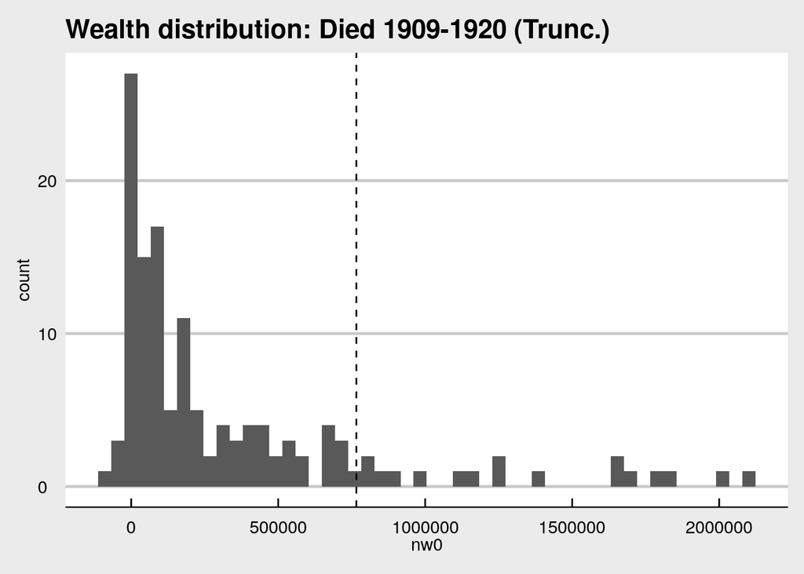

| voorletters | prepositie | achternaam | nw0 |
| --- | --- | --- | --- |
| H.P.C. | NA | Bosch van Drakestein | 786880.0 |
| C.Th. | van | Deventer | 690315.0 |
| W.A. | baron van der | Feltz | 699148.9 |
| W. | NA | Hovy | 765976.7 |
| E.H. | s’ | Jacob | 665450.2 |
| L.J.S. | van | Kempen | 787279.3 |
| J.G. | NA | Patijn | 716511.0 |
| W.J.H. | NA | Prinzen | 899497.1 |
| H. | NA | Waller | 668754.0 |
| C.H.A. | van der | Wijck | 854530.3 |

In totaal zijn dat 10 politici. Laten we van deze politici de vermogenspositie nog eens bekijken:

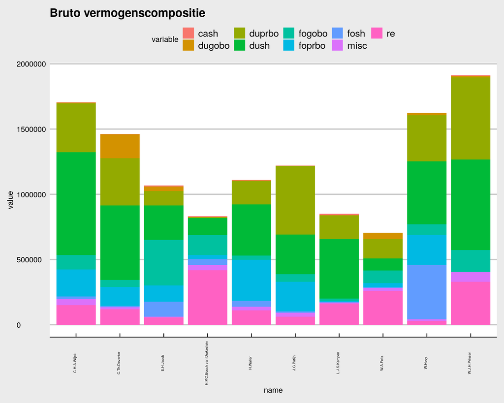